# Introdução à Ciência de Dados

Introdução à Inferência Estatística

Prof. Washington Santos da Silva

IFMG - Campus Formiga

25 de junho de 2025

## Diário de Bordo

**O que vimos até hoje?**

- Aula 1 ✅
  - Introdução e Contextualização ✅
  - O que é Ciência de Dados? ✅
  - Papéis Profissionais na Área de Dados ✅
  - Áreas de Aplicações ✅
  - Habilidades Interpessoais e Analíticas ✅
  - Apresentação da Disciplina ✅
- Aula 2 ✅
  - Metodologia CRISP-DM ✅
  - Tipos de Análise ✅
    - Descritiva ✅
    - Diagnóstica ✅
    - Preditiva ✅
    - Prescritiva ✅
  - Configurações: Git/GitHub ✅
- Aula 3 ✅
  - Introdução ao RStudio ✅
    - Criação do **seu** Projeto RStudio da Disciplina ✅
- Aula 4 ✅
  - Introdução ao Git e GitHub ✅
    - Criação do **seu** repositório do projeto RStudio da disciplina no GitHub ✅
- Aula 5 ✅
  - Breve Revisão do IDE RStudio ✅
  - Introdução ao Sistema de Publicação Quarto ✅
  - Sessão Prática Guiada com Relatório 1 ✅
    - Execução dos comandos git essenciais ✅
- Aula 6 ✅
  - Parte I ✅
    - O Relatório Junglivet e a Metodologia CRISP-DM ✅
    - Primeiro contato com a linguagem R por meio dos códigos do relatório ✅
  - Parte II ✅
    - Para alunos com projetos estruturados ✅
    - Atividade prática ✅
    - Para alunos com dificuldades técnicas ✅
    - Atendimento individualizado para estruturação de projetos ✅
- Aula 7 ✅
  - Introdução ao sistema Quarto (continuação) ✅
    - Gerar relatório no formato pdf ✅
    - Gerar relatório no formato docx ✅
  - Introdução à Linguagem R (continuação) ✅
    - Conceitos: Variáveis e observações ✅
    - Estrutura tabular organizada de dados ✅
    - Tipos e classes de dados principais em R ✅
    - Estruturas de dados: vetores e data frames ✅
- Aula 8 ✅
  - Início do estudo do pacote dplyr para manipulação de dados ✅
    - CRISP-DM: Fase 2 (Entendimento dos dados) e Fase 3 (Preparação dos dados) ✅  
      de um projeto de análise ou ciência de dados ✅
    - O que é o dplyr? ✅
    - A Filosofia *Tidy Data* (Dados Organizados) ✅
    - Dados Organizados (*Tidy Data*) ✅
    - Por que usar o dplyr? ✅
    - Fluxo de trabalho com dplyr ✅
    - Boas Práticas com dplyr ✅
    - Função dplyr::select() ✅
    - Função dplyr::filter() ✅
- Aula 9 ✅
  - Solução dos exercícios práticos sobre as funções select e filter ✅
  - Função dplyr::mutate() ✅
- Aula 10 ✅
  - Soluções dos exercícios práticos sobre a função mutate ✅
  - funções dplyr::group_by(), dplyr::summarize() e dplyr::arrange() ✅
- Aula 11 ✅
  - Metodologia CRISP-DM e Pacote dplyr ✅
  - Revisão sobre Dados Organizados (*Tidy Data*) ✅
  - Exemplos de Dados Desorganizados Comuns em Administração ✅
  - Pacote tidyr: Função pivot_longer ✅
- Aula 12 ✅
  - Metodologia CRISP-DM e o tidyverse ✅
  - Dados Organizados: Potencializando Análises ✅
- Aula 13 ✅
  - Avaliação 1 ✅
- Aula 14 ✅
  - Tipos Básicos de *joins* do pacote dplyr ✅
- Aula 15 ✅
  - Variáveis Aleatórias em Finanças ✅
  - Distribuições de Probabilidade ✅
  - Início: Distribuição Normal (ou Gaussiana) ✅
- Aula 16 ✅
  - Distribuição Normal (ou Gaussiana) - Parte 2 ✅
  - Características da Distribuição de uma VA ✅
    - Valor Esperado (Média) ✅
- Aula 17 ✅
  - Características da Distribuição de uma VA ✅
    - Variância e Desvio-Padrão ✅
    - Variância: Propriedades Básicas ✅
    - Aplicação: Valor-em-Risco (VaR) ✅
    - Assimetria e Curtose ✅
- Aula 18 ✅
  - Características da Distribuição de uma VA ✅
    - Covariância e Correlação ✅
    - Fundamentos de Simulação de Monte Carlo ✅
- Aula 19 ✅
  - Teoria da Probabilidade e Análise Estatística de Dados ✅
  - CRISP-DM e Análise Exploratória de Dados ✅
  - Análise Exploratória Numérica ✅
    - Medidas de Posição (ou de Tendência Central) ✅
    - Medidas de Variabilidade ✅
    - Medidas de Correlação ✅
- Aula 20 ✅
  - Análise Exploratória Gráfica ✅
    - Visualização de Dados e o Pacote ggplot2 ✅
    - Gráficos para Visualizar a Distribuição de Variáveis Numéricas ✅
      - Histograma ✅
      - Densidade Empírica (ou Kernel da Densidade) ✅
      - Boxplot ✅
      - Boxplot Comparativo ✅
- Aula 21 ✅
  - Gráfico Univariado para Variáveis Categóricas:
    - Gráfico de Barras (Barplot)
  - Gráficos Bivariados:
    - Gráficos de Barras Agrupadas e Empilhadas - Variáveis Categóricas
    - Gráfico de Dispersão - Variáveis Numéricas
  - Gráfico para Séries Temporais:
    - Gráfico de Linha Univariado (1 Série Temporal)
    - Gráfico de Linha Bivariado (2 Séries Temporais)
- Aula 22 ✅
  - Lista de Exercícios - Treino para Avaliação 2
- Aula 23 ✅
  - Avaliação 2

## Nesta Aula

**Tópicos**

- CRISP-DM: Fase 4 - Modelagem/Análise
- Introdução à Inferência Estatística
  - População e Amostra
  - Amostragem: Conceitos Básicos
  - Parâmetro, Estimador, Estimativa e Estatística

## Arquivo para esta Aula (24)

**Instruções**

- Abra o RStudio e o seu Projeto da Disciplina
- Crie a subpasta **14-relatorio** dentro da pasta **relatorios**.
- Acesse o site da disciplina e baixe o arquivo **14-relatorio.zip**
- Descompacte o arquivo, copie/recorte o arquivo `14-relatorio.qmd` e cole dentro da subpasta 14-relatorio.

**Diretrizes para Aulas Mais Produtivas**

🔊 **Mantenha conversas em volume baixo**

⌨️ **Código com método:**

95% dos erros são evitáveis com:

- Atenção na digitação
- Respeitar a sequência lógica de etapas
- Revisão antes de pedir ajuda

🤝 **Inteligência colaborativa:**

- Compartilhe conhecimento
- Resolva questões técnicas simples com colegas próximos
- Reserve ao professor as dúvidas conceituais complexas

💪 **Capacidade de Resolver Problemas**

Cada erro resolvido é uma evolução da sua habilidade analítica

## Metodologia CRISP-DM

Fases da Metodologia CRISP-DM

## CRISP-DM: Onde Estamos?

**Nossa Jornada na Disciplina -> Progresso na Metodologia CRISP-DM**

| **Fase/Componente** | **Atividades Realizadas** |
| --- | --- |
| **Fase 1 - Entendimento do Negócio** ✅ | Relatório Junglivet: definição de problemas e objetivos |
| **Fase 2 - Entendimento dos Dados** ✅ | Importação e exploração inicial com tidyverse (`here`, `readr`, `dplyr`…) |
| **Fase 3 - Preparação dos Dados** ✅ | Transformação/organização/limpeza e AED com tidyverse (`tidyr`, `dplyr`, `ggplot2`…) |
| **🔗 Teoria da Probabilidade** ✅ | Variáveis aleatórias, distribuição normal, valor esperado, variância/desvio-padrão, correlação, simulação |
| **Fase 4 - Modelagem/Análise** 🔄 | **Introdução à Inferência Estatística** → Transformar dados em insights estatisticamente fundamentados |

## Conexão com CRISP-DM

**Onde a Inferência Estatística se Encaixa?**

**🔄 Inferência permeia todo o processo CRISP-DM:**

| **Fase** | **Aplicação da Inferência Estatística** |
| --- | --- |
| **Fase 2 - Entendimento dos Dados** | Usar **amostras** para entender a **população** |
| **Fase 3 - Preparação** | Verificar a **representatividade** dos dados/amostra |
| **Fase 4 - Análise/Modelagem** | Estimar **parâmetros**, quantificar **incerteza**, **Previsões** |
| **Fase 5 - Validação** | Validar conclusões com **rigor estatístico** |

**💡 Resultado:** Decisões baseadas em evidências, não apenas em intuição ou análise qualitativa!

## Caso Junglivet Whisky Company

**Fase 1: Entendimento do Negócio - (01-relatorio.qmd)**

No caso da destilaria Junglivet, identicamos que o problema de negócio, o objetivo da análise e o critério de sucesso:

- **Problema de negócio**: Queda na qualidade do whisky produzido.
- **Objetivo**: Identificar possíveis causas da redução de qualidade.
- **Critério de sucesso**: Encontrar fatores que influenciam negativamente a qualidade do whisky.
- Fizemos análises **descritiva e diangóstica iniciais** para identificar as possíveis causas do problema com base nos dados disponíveis.

## Caso Junglivet Whisky Company

**Relação entre fornecedor e qualidade do whisky**

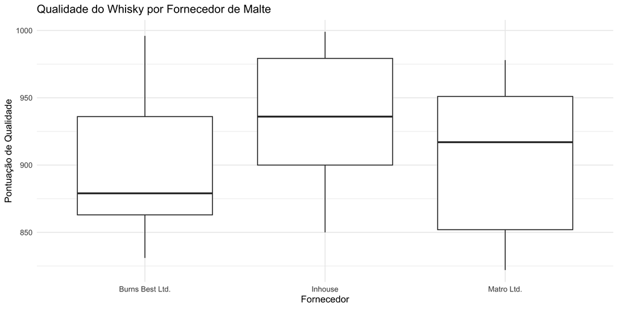

## Caso Junglivet Whisky Company

**Relação entre fornecedor e qualidade do whisky**

Os resultados da análise preliminar dos dados da linha de produção da Junglivet Whisky Company, indicaram que:

> O fornecedor de malte **parece** ser um fator significativo na qualidade do whisky

Pois, analisando o **boxplot comparativo** concluimos que:

- Os whiskies produzidos com matéria-prima da “Burns Best Ltd.” tendem a ter qualidade mediana inferior.
- Os whiskies produzidos com a matéria-prima proveniente da “Matro Ltd.” apresentam grande variabilidade na qualidade da bebida, com alguns apresentando qualidade inferior aos produzidos com insumo da “Burns Best Ltd.”
- Os whiskies produzidos com matéria-prima própria (“Inhouse”) tentem a apresentar qualidade superior pelo indicador de qualidade baseado nos testes de desgustação.

## Caso Junglivet Whisky Company

**Há de fato diferenças na qualidade do whisky devido ao fornecedor de malte?**

**Limitações da Análise Apenas Descritiva:**

Nossas conclusões se basearam apenas na **análise exploratória visual** dos dados. Mas isso é suficiente para decisões cientificamente embasadas?

Questões **Científicas Fundamentais:**

| **Tipo de Evidência** | **Pergunta-Chave** | **Por que Importa?** |
| --- | --- | --- |
| **Significância Estatística** | As diferenças são **reais** ou apenas **acaso**? | Evitar decisões baseadas em variabilidade natural |
| **Significância Prática** | As diferenças são **grandes o suficiente** para importar? | Mudanças custosas precisam justificar o investimento |
| **Quantificação da Incerteza** | Qual nossa **confiança** nas estimativas? | Gestores precisam conhecer os **riscos** das decisões |

**A Solução: Análise Estatística Moderna**

> Além de detectar diferenças, precisamos **quantificar sua magnitude** (tamanho do efeito), **estimar intervalos de confiança** e **avaliar relevância prática** - não apenas significância estatística.

**📈 Próximo Passo:** **Fundamentos de inferência estatística moderna** para recomendações e decisões baseadas em dados e com **rigor científico!**

# População e Amostra

## Por que Esta Distinção é Fundamental?

**O Desafio Central do Analista de Dados**

- Analistas de dados enfrentam constantemente esta realidade: precisam tirar conclusões sobre grupos muito grandes (população) baseando-se apenas em informações de grupos menores (amostra).
- Esta distinção determina como interpretamos resultados e quanta confiança podemos ter em nossas conclusões.
- A qualidade da inferência depende de quão bem nossa amostra representa a população de interesse.
- Esta é uma das questões mais importantes que todo analista deve sempre considerar antes de fazer qualquer análise ou recomendação.

## População: O Conjunto Completo

**Definição e Características**

**População** é o conjunto completo de elementos sobre os quais queremos tirar conclusões. Importante: não se refere apenas a pessoas, mas a qualquer conjunto de interesse.

**Características Principais:**

A população possui **parâmetros** - valores fixos (mas geralmente desconhecidos) representados por letras gregas: média populacional ($\mu$), desvio padrão ($\sigma$), proporção ($p$).

O tamanho é representado por $N$ e pode ser finito (funcionários de uma empresa) ou infinito (lançamentos de moeda).

**Exemplos:** Todos os clientes de um banco, todos os produtos de uma linha de produção, todas as transações de uma empresa em um ano.

## Amostra: O Subconjunto Observado

**Definição e Características**

**Amostra** é um subconjunto da população que efetivamente observamos e sobre o qual coletamos dados. É nossa “janela” para entender a população.

**Características Principais:**

A amostra produz **estatísticas** - valores calculados dos dados observados, representados por letras latinas: média amostral ($\bar{x}$), desvio-padrão ($s$), proporção ($\hat{p}$).

O tamanho é representado por $n$ (sempre menor que $N$). Diferentemente dos parâmetros, as estatísticas são variáveis aleatórias que mudam entre amostras.

**Ponto Crucial:** Usamos estatísticas amostrais como estimadores dos parâmetros populacionais desconhecidos.

## A Relação Fundamental

### População

**Parâmetros (fixos, desconhecidos):**

- Tamanho: $N$
- Média: $\mu$
- Desvio-padrão: $\sigma$
- Proporção: $p$

**População:** 46.000 barris de whisky produzidos

### Amostra

**Estatísticas:**

- Tamanho: $n$
- Média: $\bar{x}$
- Desvio-padrão: $s$
- Proporção: $\hat{p}$

**Importante**

**Inferência Estatística:** Usamos estatísticas amostrais para **estimar** parâmetros populacionais (desconhecidos), com incerteza quantificável.

## Por que Trabalhamos com Amostras?

**Limitações Práticas**

**Impossibilidade:** Estudar toda a população é frequentemente impossível

**Custo e Tempo:** Censo completo pode ter um custo e tempo proibitivos.

**Natureza Destrutiva:** Alguns testes destroem o produto (durabilidade, qualidade).

**Eficiência:** Amostra bem coletada fornece precisão quase igual a censo completo, com fração do custo.

**Conclusão:** A questão não é se usar amostras, mas como coletar e analisar amostras para conclusões válidas.

## Exemplo: Qualidade do Whisky

**Situação Prática**

Analista da destilaria Junglivet precisa avaliar qualidade média de 46.000 barris produzidos em 2024. Testar **todos** seria impossível (destruiria produto). Solução: **amostra representativa**.

Este exemplo ilustra como usamos informações limitadas (**amostra**) para fazer **inferências** sobre **populações**.

## Qualidade do Whisky: População e Amostra

```
# A tibble: 3 × 3
  Característica      `Valor Real` Significado
  <chr>               <chr>        <chr>
1 Tamanho (N)         46.000       Total de barris produzidos em 2024
2 Qualidade média (μ) 7.2          Qualidade média de toda a produção
3 Desvio padrão (σ)   0.91         Variabilidade da qualidade dos barris
```

```
# A tibble: 3 × 3
  Característica      `Valor Calculado` Interpretação
  <chr>                           <dbl> <chr>
1 Tamanho (n)                     50    amostra
2 Qualidade média (x̄)              7.22 estimativa de μ
3 Desvio- padrão (s)               1    estimativa do σ
```

## Comparação: Parâmetros vs Estimativas

```
# A tibble: 3 × 4
  Medida          População  Amostra  `Qualidade da Estimativa`
  <chr>           <chr>      <chr>    <chr>
1 Tamanho         N = 46.000 n = 50   Amostra = 0,11% da população
2 Qualidade Média μ = 7.2    x̄ = 7.22 Boa estimativa
3 Desvio Padrão   σ = 0.91   s = 1    Boa estimativa
```

## Verificação Visual da Representatividade

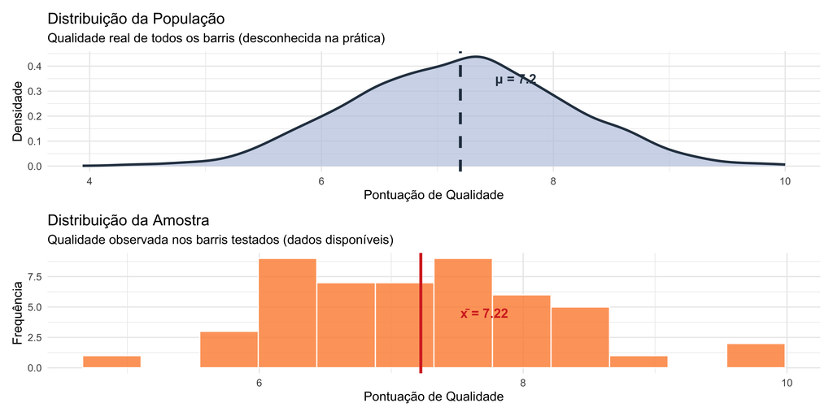

## Interpretação da Comparação

**Análise dos Resultados**

**Formas das Distribuições:** Ambas apresentam distribuições aproximadamente normais, indicando que a amostra capturou adequadamente a forma populacional.

**Centros:** Média populacional ($\mu = 7.20$) e amostral ($\bar{x} = 7.22$) são muito próximas.

**Variabilidade:** Dispersão amostral é consistente com a variabilidade populacional.

**Limitação Prática:** Na realidade, não temos dados populacionais para esta comparação. Por isso analistas dependem de **técnicas adequadas de amostragem** e **métodos estatísticos** para quantificar incerteza.

## Exemplo: Satisfação de Clientes

**Cenário Empresarial**

Analista de e-commerce com 50.000 clientes ativos precisa estimar satisfação média para estratégias de retenção. Entrevistar todos seria proibitivo. Solução: amostra de 80 clientes para obter uma estimativa confiável.

## Satisfação de Clientes: População e Amostra

```
# A tibble: 4 × 2
  Característica           `Valor Verdadeiro`
  <chr>                    <chr>
1 Total de clientes        50.000
2 Satisfação média (μ)     7.49
3 Desvio padrão (σ)        1.18
4 % muito satisfeitos (≥8) 33.8%
```

```
# A tibble: 4 × 3
  Resultado              Valor Interpretação
  <chr>                  <chr> <chr>
1 Clientes entrevistados 80    Tamanho da amostra
2 Satisfação média (x̄)   7.632 estimativa de μ
3 Desvio padrão (s)      1.229 estimativa do σ
4 % muito satisfeitos    40%   estimativa da % de clientes altamente satisfeitos
```

## Quiz 1

**Questão**

**Cenário:** Empresa com 8.000 garrafas de vinho. Analista seleciona 120 garrafas para avaliação de qualidade por especialistas.

**Identifique:**

1. Qual é a população?
2. Qual é a amostra?
3. O que representa $\mu$?
4. O que representa $\bar{x}$?
5. Por que não avaliar todas as garrafas?

## Respostas do Quiz 1

**Análise**

1. **População:** Todas as 8.000 garrafas no estoque - totalidade sobre a qual queremos conclusões.
2. **Amostra:** 120 garrafas efetivamente avaliadas pelos especialistas.
3. $\mu$ = Qualidade média verdadeira de todas as 8.000 garrafas - parâmetro fixo mas desconhecido.
4. $\bar{x}$: Qualidade média das 120 garrafas avaliadas - estimativa de $\mu$.
5. **Limitações:** Custo elevado, tempo excessivo, e possível natureza destrutiva dos testes.

## Quiz 2

**Questão**

**Cenário:** Rede com 1.200 farmácias. Analista seleciona 80 lojas para estudar ticket médio.

**Identifique:**

1. Qual é a população?
2. Qual é a amostra?
3. O que representa $\mu$?
4. O que representa $\bar{x}$?
5. Vantagens da abordagem amostral?

## Respostas do Quiz 2

**Análise**

1. **População:** Todas as 1.200 lojas da rede.
2. **Amostra**: 80 lojas selecionadas para análise.
3. $\mu$ = Ticket médio verdadeiro de todas as 1.200 lojas.
4. $\bar{x}$ = Ticket médio calculado das 80 lojas analisadas.
5. **Vantagens**: Economia significativa de tempo e recursos, conclusões mais rápidas para decisões, precisão adequada para fins práticos, análises mais detalhadas possíveis.

# Amostragem

## Por que Amostragem é Necessária?

**O Dilema do Analista de Dados**

**Situação Ideal**: Estudar toda a população para obter informações completas.

**Realidade Prática**: Estudar toda a população é frequentemente:

- **Impossível**: Populações infinitas ou inacessíveis
- **Inviável**: Custo e tempo excessivos
- **Destrutivo**: Testes que danificam produtos
- **Desnecessário**: Amostras bem planejadas fornecem precisão adequada

**Exemplo**: Pesquisar 100.000 clientes custa R$ 500.000 e leva 6 meses. Uma amostra de 1.000 clientes custa R$ 5.000, leva 1 semana, e fornece precisão suficiente.

**Conclusão**: A amostragem permite obter informações confiáveis de forma eficiente.

## O que é Amostragem?

**Definição e Características**

**Amostragem** é o processo de selecionar um subconjunto representativo de uma população.

**Características de uma Boa Amostra:**

- **Representativa**: Reflete características da população
- **Tamanho adequado**: Equilibra precisão e custo
- **Sem viés**: Processo não favorece grupos específicos
- **Aleatória**: Em amostragem probabilística, probabilidade conhecida de seleção

**Princípio fundamental**: Apenas amostras probabilísticas permitem inferência estatística válida.

## Tipos de Amostragem Probabilística

**Métodos Principais**

**Amostragem Aleatória Simples**

- Cada elemento tem a mesma probabilidade de seleção
- Base da teoria estatística clássica
- **Exemplo**:

> Considere que você possui uma lista cada um com o nome de um morador de uma cidade. Você sorteia 100 nomes ao acaso, sem nenhum critério especial — exatamente como em uma loteria.

👉 Todos têm a mesma chance de serem escolhidos, independentemente da idade, bairro, renda, etc.

## Tipos de Amostragem Probabilística

**Amostragem Estratificada**

- Uma população heterogênea é dividida em grupos homogêneos
- Garante a representação proporcional dos subgrupos
- **Exemplo**:

> Suponha que você queira entrevistar os estudantes do IFMG - Campus Formiga, e quer garantir que todos os cursos estejam representados. Você estratifica os alunos por curso (ex: Engenharia, Administração, Computação..), sendo que o número de amostras de cada curso será proporcional à proporção de alunos de cada curso em relação ao total de alunos.

👉 Garante que todos os cursos (estratos) estejam proporcionalmente representados na amostra.

## Tipos de Amostragem Probabilística

**Amostragem por Conglomerados**

- Seleção de grupos heterogêneos completos
- Útil quando listas populacionais são difíceis
- **Exemplo**:

> Você quer entrevistar pessoas em uma grande cidade, mas não tem uma lista de todos os moradores. Então, sorteia 10 quarteirões aleatórios, e entrevista todos os moradores desses quarteirões.

👉 Cada quarteirão (conglomerado) deve refletir a diversidade da cidade como um todo.

## Tipos de Amostragem Probabilística

**Amostragem Sistemática**

- Seleção em intervalos regulares
- Simples de implementar
- **Exemplo**:

> Você tem uma lista de 10.000 funcionários de uma empresa, em ordem alfabética. Decide entrevistar 1.000 deles. Sorteia um número entre 1 e 10 (por exemplo, 7) e depois seleciona cada 10ª pessoa a partir do 7º nome na lista: 7, 17, 27, 37…

👉 Simples de aplicar, mas precisa de uma lista ordenada da população.

## Amostragem Aleatória Simples: Teoria

**Conceito Matemático**

**Definição**: Cada elemento da população tem a mesma probabilidade de seleção.

**Probabilidade de seleção** para população $N$ e amostra $n$:
$$P = \frac{n}{N}$$

**Quando usar**: População homogênea, lista completa disponível, análise simples prioritária.

**Vantagem**: Teoria estatística simples.

## A Função `slice_sample()` do dplyr

**Para que serve `slice_sample()`?**

A função `slice_sample()` seleciona **linhas aleatórias** de uma data frame.

É ideal para realizar **amostragem aleatória simples**

- Sintaxe básica

```r
slice_sample(.data, n = <tamanho da amostra>)
```

- `.data`: o data frame
- `n`: número de linhas a serem sorteadas
- Exemplo com `mtcars`

```r
# Selecionar 5 carros aleatórios da base mtcars
amostra <- mtcars %>%
  slice_sample(n = 5)

amostra
```

- Reprodutibilidade

Use `set.seed()` antes para obter os mesmos resultados toda vez.

```r
set.seed(123)
mtcars %>% slice_sample(n = 5)
```

## Amostragem Aleatória Simples no R

**Exemplo com Dados Municipais do PNUD (`pnud_muni`)**

```r
# Carregar pacotes
library(abjData)   # Fornece dados municipais do PNUD

# Carregar a base completa
data("pnud_muni")

# Filtrar apenas os dados mais recentes
dados_recentes <- pnud_muni %>%
  filter(ano == max(ano))  # ano mais recente disponível

# Verificar estrutura
glimpse(dados_recentes)
```

```
Rows: 5,565
Columns: 124
$ uf                    <int> 11, 11, 11, 11, 11, 11, 11, 11, 11, 11, 11, 11, …
$ ano                   <int> 2010, 2010, 2010, 2010, 2010, 2010, 2010, 2010, …
$ codmun6               <int> 110001, 110002, 110003, 110004, 110005, 110006, …
$ codmun7               <int> 1100015, 1100023, 1100031, 1100049, 1100056, 110…
$ municipio             <chr> "ALTA FLORESTA D'OESTE", "ARIQUEMES", "CABIXI", …
$ espvida               <dbl> 70.75, 73.36, 70.39, 74.27, 72.94, 73.81, 71.45,…
$ fectot                <dbl> 2.24, 1.91, 2.15, 1.90, 2.12, 1.89, 2.29, 2.72, …
$ mort1                 <dbl> 23.80, 19.20, 24.80, 14.30, 18.10, 16.10, 21.90,…
$ mort5                 <dbl> 25.49, 20.53, 26.58, 15.38, 19.42, 17.28, 23.45,…
$ razdep                <dbl> 47.37, 46.68, 48.12, 43.79, 45.67, 45.82, 46.32,…
$ t_env                 <dbl> 5.84, 4.36, 6.87, 5.57, 6.44, 7.51, 5.67, 3.82, …
$ e_anosestudo          <dbl> 8.67, 9.18, 10.09, 9.74, 10.22, 10.40, 9.82, 9.2…
$ t_atraso_0_basico     <dbl> 57.62, 58.43, 66.22, 66.69, 72.15, 68.55, 67.01,…
```

[output cut: 111 more lines]

## Amostragem Estratificada com o pacote `sampling`

**Exemplo com Dados Municipais do PNUD (`pnud_muni`)**

```r
library(sampling)    # Técnicas clássicas de amostragem

# Carregar base de dados e filtrar o ano mais recente
data("pnud_muni")
dados_recentes <- pnud_muni %>%
  filter(ano == max(ano)) %>%
  select(uf, municipio, pop, espvida, rdpc, idhm)

# Tamanho total da amostra desejada
n_total <- 150

# Calcular tamanho proporcional da amostra por UF
tamanhos <- dados_recentes %>%
  # Contar o número de municípios em cada UF
  count(uf, name = "n_uf") %>%
  # Calcular a proporção de municípios da UF em relação ao total de municípios
  mutate(
    prop = n_uf / sum(n_uf),
    # Determinar o tamanho da amostra da UF proporcional ao total desejado
    n_amostra = round(prop * n_total),
    # Corrigir possíveis casos com zero observações (garante mínimo de 1)
    n_amostra = if_else(n_amostra == 0, 1L, n_amostra)
  )


# Realizar amostragem estratificada proporcional
set.seed(123)
amostra_ids <- sampling::strata(
  data = dados_recentes,           # data frame com a população (municípios do ano mais recente)
  stratanames = "uf",              # variável que define os estratos
  size = tamanhos$n_amostra,       # número de unidades a serem sorteadas por estrato (UF)
  method = "srswor"                # aas sem reposição
)

# Selecionar observações da amostra
amostra_proporcional <- dados_recentes[amostra_ids$ID_unit, ]
```

👉 A função `strata()` sorteia municípios **proporcionalmente à quantidade por UF**, garantindo pelo menos 1 município por estado.

👉 `ID_unit` contém os índices sorteados que usamos para extrair a amostra final.

## Visualizando a Amostra Estratificada

**Quantos Municípios Foram Sorteados por UF?**

```r
# Contar número de municípios sorteados por UF
amostra_proporcional %>%
  count(uf, name = "n_sorteados") %>%
  arrange(desc(n_sorteados))
```

```
# A tibble: 27 × 2
      uf n_sorteados
   <int>       <int>
 1    31          23
 2    35          17
 3    43          13
 4    29          11
 5    41          11
 6    42           8
 7    52           7
 8    21           6
 9    22           6
10    25           6
# ℹ 17 more rows
```

👉 Como usamos alocação proporcional, estados com mais municípios no total também contribuem com mais municípios na amostra.

👉 Isso reforça a ideia de **representatividade proporcional** da amostragem estratificada.

## Problemas da Amostragem por Conveniência

**Limitações Graves**

**Definição**: Seleção de elementos mais fáceis de acessar, sem aleatoriedade.

**Problemas**:

- **Viés sistemático**: Grupos são sub/super-representados
- **Erro não quantificável**: Impossível calcular margens de erro
- **Generalização inválida**: Resultados limitados à amostra
- **Decisões equivocadas**: Conclusões podem ser enganosas

**Quando aceitar**: Apenas estudos exploratórios, com ressalvas explícitas sobre limitações.

## Amostragem e Inferência Estatística

**Base de Toda Inferência**

**Amostragem adequada é fundamental para**:

- **Intervalos de confiança**: Aleatoriedade valida propriedades teóricas
- **Testes de hipóteses**: Independência é pressuposto dos testes
- **Bootstrap**: Eficácia depende de amostra representativa
- **Generalização**: Apenas amostras probabilísticas permitem inferência válida

**Princípio**: Qualidade da amostragem determina validade de toda análise posterior.

## Síntese: Conceitos Essenciais

**Pontos-Chave**

**Necessidade**: Realizar um censo completo é frequentemente inviável, caro ou desnecessário.

**Métodos Principais Vistos**:

- **AAS (Amostragem Aleatória Simples)**: base teórica da inferência estatística
- **Amostragem Estratificada**: assegura representatividade por subgrupos

**Ferramentas em R**:

- `slice_sample()` do **dplyr**: simples e intuitiva para AAS
- `sampling::strata()`: apropriada para amostragem estratificada com controle do plano amostral

**Qualidade da Amostra**:

- Apenas **amostras probabilísticas** permitem inferência estatística válida
- **Amostragem por conveniência** não permite generalizações confiáveis

**Inferência Estatística**:

- A validade de intervalos de confiança, testes de hipóteses e métodos de simulação depende da aleatoriedade da amostra

**Responsabilidade Profissional**:

- O analista de dados deve sempre explicitar e justificar o método de amostragem adotado

## Exercício

**Objetivo**

Aplicar os conceitos aprendidos de amostragem aos dados do PNUD:

1. Filtrar os dados para o ano mais recente disponível
2. Criar uma **amostra estratificada proporcional por UF** com 150 municípios
3. Estime a média do IDHM da amostra estratificada
- Dicas:
- Use a base `pnud_muni` do pacote `abjData`
- Utilize `set.seed(123)` para reprodutibilidade
- Para a amostragem estratificada, siga o padrão visto nos slides anteriores

**Código comentado**

```r
# Carregar dados
data("pnud_muni")

# filtra para o ano mais recente
dados <- pnud_muni %>%
  filter(ano == max(ano)) %>%
  select(uf, municipio, idhm)

# Tamanho proporcional por UF para 150 municípios
n_total <- 150
tamanhos <- dados %>%
  count(uf, name = "n_uf") %>%
  mutate(
    prop = n_uf / sum(n_uf),
    n_amostra = round(prop * n_total),
    n_amostra = if_else(n_amostra == 0, 1L, n_amostra)
  )

# Verificar tamanhos por UF
tamanhos
```

```
# A tibble: 27 × 4
      uf  n_uf    prop n_amostra
   <int> <int>   <dbl>     <dbl>
 1    11    52 0.00934         1
 2    12    22 0.00395         1
 3    13    62 0.0111          2
 4    14    15 0.00270         1
 5    15   143 0.0257          4
 6    16    16 0.00288         1
 7    17   139 0.0250          4
 8    21   217 0.0390          6
 9    22   224 0.0403          6
10    23   184 0.0331          5
# ℹ 17 more rows
```

```r
# Amostragem Estratificada Proporcional
set.seed(123)
amostra_ids <- sampling::strata(
  data = dados,
  stratanames = "uf",
  size = tamanhos$n_amostra,
  method = "srswor"
)
amostra_proporcional <- dados[amostra_ids$ID_unit, ]

# Média da estratificada
mean(amostra_proporcional$idhm)
```

```
[1] 0.66065
```

# Parâmetro, Estimador, Estatística e Estimativa

## Notação e Conceitos

|  | População | Amostra |
| --- | --- | --- |
| Símbolos | $\mu$, $\sigma$, $p$, $\rho$ | $\bar{x}$, $s$, $\hat{p}$, $r$ |
| Fixo ou aleatório? | Fixo (desconhecido) | Aleatório |
| Obtido por | Censo/dados históricos | Amostragem |
| Objetivo | Verdade a descobrir | Instrumento de inferência |

## Estimador Pontual (Fórmula)

| Estimador | Fórmula | O que faz |
| --- | --- | --- |
| Média amostral | $\bar{x} = \frac{\sum_{i=1}^{n} X_i}{n}$ | Estima $\mu$ |
| Desvio amostral | $s = \sqrt{\frac{\sum_{i=1}^{n} (X_i - \bar{X})^2}{n-1}}$ | Estima $\sigma$ |
| Proporção amostral | $\hat{p} = \frac{X}{n}$ | Estima $p$ |
| Correlação amostral | $r = \frac{\sum (X_i - \bar{X})(Y_i - \bar{Y})}{(n-1)S_X S_Y}$ | Estima $\rho$ |

## Conceitos Centrais

**Estimador, Estatística e Estimativa**

- **Estimador**: Fórmula que aplicamos aos dados da amostra para obter um valor que estima uma parâmetro populacional.
- **Estatística**: É qualquer função dos dados da amostra. Todo estimador é uma estatística, mas nem toda estatística é um **bom** estimador.
- **Estimativas**: Resultados numéricos obtidos ao aplicar os estimadores

## Distinção Fundamental

### Estatística e Estimador

- São **variáveis aleatórias**
- **Natureza**: Função dos dados
- **Varia**: Entre amostras
- **Exemplo**: $\bar{X} = \frac{\sum X_i}{n}$
- **Distribuição**: Tem sua própria distribuição (**distribuição amostral**)

### Estimativa

- **É**: Um **número fixo**
- **Natureza**: Valor calculado
- **Fixo**: Para uma amostra específica
- **Exemplo**: $\bar{x} = 7.82$
- **Interpretação**: Realização de um estimador ou estatística

## Quiz 3

**Identifique: Parâmetro, Estimador, Estatística ou Estimativa?**

Uma empresa de e-commerce analisa seus pedidos:

1. A fórmula $S^2 = \frac{\sum(X_i - \bar{X})^2}{n-1}$ para calcular variância
2. O valor R$ 127,50 calculado como média de 1.000 pedidos
3. A verdadeira proporção de clientes satisfeitos (nota ≥ 8)
4. A variável aleatória $\hat{p}$ = proporção amostral de satisfeitos
5. O desvio padrão σ = R$ 45,00 de todos os pedidos históricos

## Quiz 3

**Respostas**

1. **Estimador** (fórmula/método para estimar $\sigma^2$)
2. **Estimativa** (valor numérico específico de $\bar{X}$)
3. **Parâmetro** ($p$ - proporção populacional)
4. **Estatística** (variável aleatória)
5. **Parâmetro** ($\sigma$ - desvio padrão populacional)

## Atualizando os Repositórios

**Instruções**

1. No terminal do RStudio, verifique quais arquivos/pastas foram modificados ou criados com:

```bash
git status
```

2. Você pode adicionar todos os arquivos de uma vez com:

```bash
git add .
```

3. Execute git status novamente para confirmar que todos os arquivos foram adicionados (aparecerão em verde sob “*Changes to be committed*”):

```bash
git status
```

4. Se tudo estiver em verde, faça um commit com uma mensagem descritiva:

```bash
git commit -m "atualizacoes aula 24"
```

5. Se algum arquivo ou pasta ainda aparecer em vermelho após o segundo git status, adicione as pastas/arquivos um por um:

```bash
git add relatorios/13-relatorio/13-relatorio.qmd
```

6. Execute git status novamente e faça o commit quando todos os arquivos estiverem em verde:

```bash
git commit -m "atualizacoes aula 24"
```

7. Envie o repositório local atualizado para o GitHub:

```bash
git push origin main
```